# RStudio + Git = 🚀

15.7.2020

## R Studio?

- *Integrated development environment* (IDE)  
  -> Editor, Console, Plots, Versioning and more
- *R* is a widely spread data science language
- *RStudio* is developed from useRs for useRs
- It’s free and open source ❤️

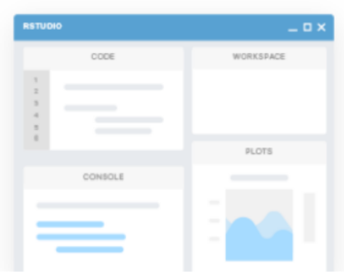

## Pane Layout (left)!

### Editor

- Show code in new window
- Jump to function (F2)
- File navigation
- Multicursor

### Console

Execute commands  
- Print output - Command history

### R Notebooks

[figure not shown]

## Pane Layout (right)!

### Enviroment, History

- Additional Panes

### Files

- Browse files / rename
- `setwd()` [MORE]
- open native file browser […]

### Packages

- `library()` / `detach()`
- `install.packages()`

[figure not shown]

## Keyboard Shortcuts 1!

### Code snippets

Text macros that are used for quickly inserting common snippets of code ([see Blog](https://support.rstudio.com/hc/en-us/articles/204463668-Code-Snippets)). - Try `fun`, `lib`, `apply`, …  
- Type `fun` and press `TAB` for shifting through arguments

[figure not shown]

### Test out

```r
# type `fun` and press TAB for shifting through arguments
ffun
ib
apply

# press CTRL+I for reintending code
test <- function() {
   hello <- "hello"
  if(is.character(hello)){
    print(hello)
          print("world")
      print("how are you?")
  }
   print(" - I feel obeserved")
}
test()
```

## Keyboard Shortcuts 2!

Press `SHIFT+ALT+K` for “all” shortcuts:

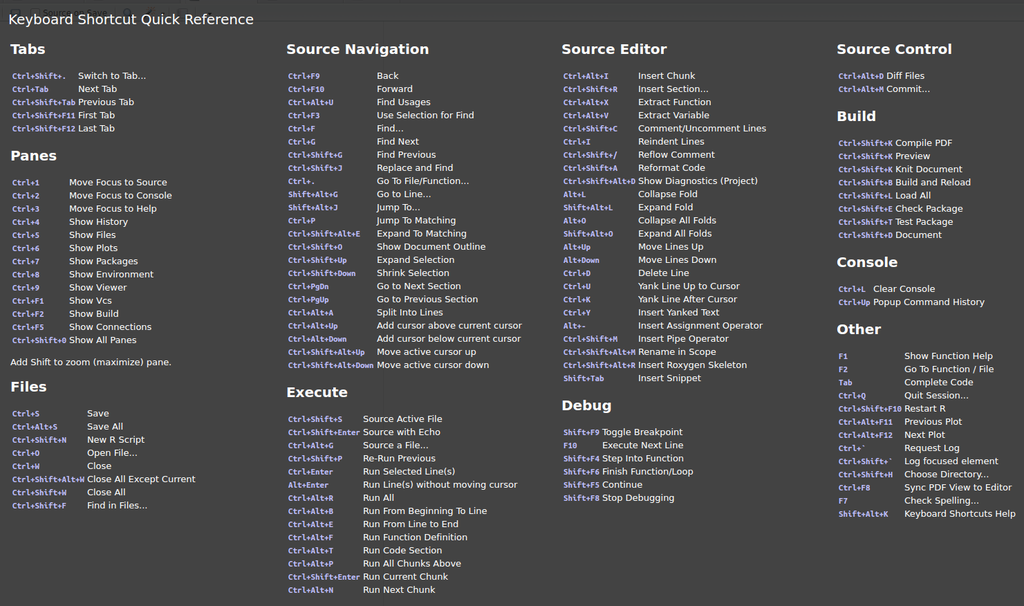

## Cheatsheets!

Open cheat sheets for `ggplot2`, `markdown`, and `more` directly from the menu bar:

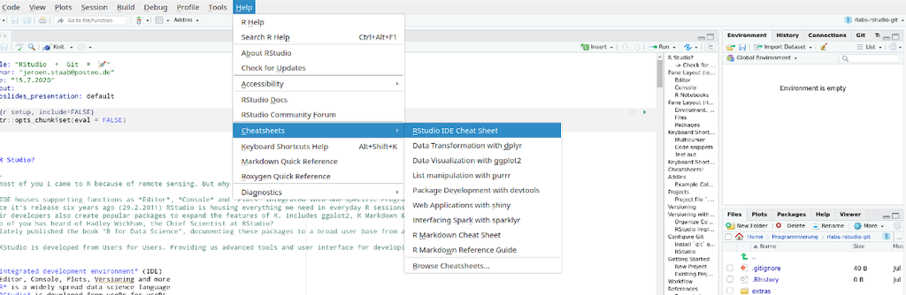

## Addins

How to install RStudio Addins?

```r
# install.packages("addinslist")
addinslist:::addinslistAddin()
```

### Example Color Picker

- Browse Addins
- Install `colourpicker`
- Click `Addins > Colour picker`
- Returns a vector  
  `c("red", "black", "green", "purple")`  
  see also `colorHelper()`

[figure not shown]

## Projects

You already organize your files in folders.  
Why not add an extra file organizing your R sessions?

### Project file `.Rproj`

- Automatically `setwd()`
- Load `.Rdata` environment
- Load `.Rhistory`
- Easily switch between projects
- Build packages
- Versioning with `git`

[figure not shown]

## Versioning

`edit -> save as`  
File name includes date and message

[figure not shown]

## Versioning with Git

edit -> save `-> stage -> commit`  
Commit includes date and message  
Versioning tools like `git` keeps track of file changes

### Organize Commits

[figure not shown]

### RStudio Implementation

[figure not shown]

## Configure Git

### Install `git` on your computer

- Visit [git-scm.com](https://git-scm.com/downloads)

[figure not shown]

### RStudio

- Global options

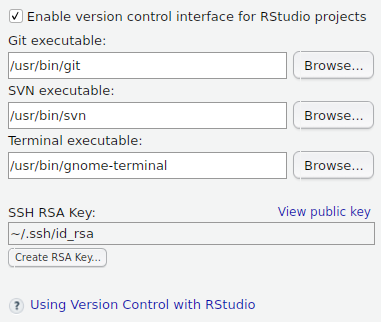

- Project options

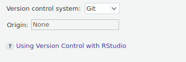

- New pane (topright)

[figure not shown]

- Interact w. cloud (opt-in)  
  e.g. Github / Bitbucket

## Getting Started…

### … 1. Rstudio Project

`Menu > File > New Project`

[figure not shown]

### … 2. Git Repository

- Open directory in `terminal`.
- Type `git init`
- `Restart` RStudio.

> Troubleshoot:  
> Check project options.

## Workflow

- Stage: Select file for next commit. Freezes state.
- Commit: Create new node in time line. Add a message.
- Push & pull: Interact with remote repository.

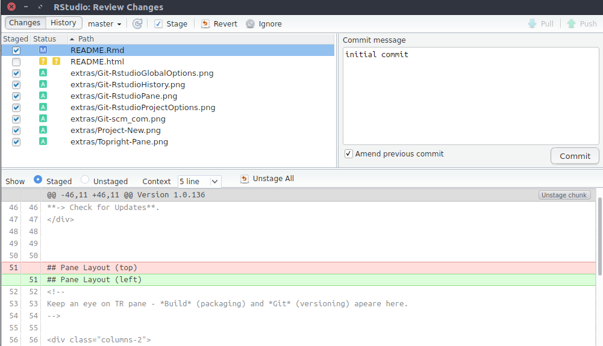

## References

Rstudio  
- [Some RStudio Tipps](https://www.r-bloggers.com/rstudio-ide-easy-tricks-you-mightve-missed/)  
- [R Notebooks](http://rmarkdown.rstudio.com/r_notebooks.html)  
- [Code Snippets](https://support.rstudio.com/hc/en-us/articles/204463668-Code-Snippets?version=1.0.136&mode=desktop)  
- [Colour Picker Addin](https://www.r-bloggers.com/an-awesome-rstudio-addin-for-selecting-colours-and-another-for-adding-marginal-density-plots-to-ggplot2/)

Git and SVN  
- [Version Control in RStudio](https://support.rstudio.com/hc/en-us/articles/200532077-Version-Control-with-Git-and-SVN)  
- [Git Documentation](https://git-scm.com/doc)

### Presentation

- [Access on github](https://github.com/georoen/rlabs-rstudio-git/blob/master/rlabs.pdf)  
  github.com/georoen

[figure not shown]